# Reproducible Research: Peer Assessment 1

## Loading and preprocessing the data

```r
library(ggplot2)
library(sqldf)
library(mice)
setwd("C:\\Coursera\\RepData_PeerAssessment1")
repData <- read.csv(file="activity.csv", header=TRUE,sep=",")
```

## What is mean total number of steps taken per day?

Mean total number of steps taken per day

```r
tsteps <- aggregate(steps ~ date, data=repData, FUN=sum)
summary(tsteps)
```

```
##          date        steps
##  2012-10-02: 1   Min.   :   41
##  2012-10-03: 1   1st Qu.: 8841
##  2012-10-04: 1   Median :10765
##  2012-10-05: 1   Mean   :10766
##  2012-10-06: 1   3rd Qu.:13294
##  2012-10-07: 1   Max.   :21194
##  (Other)   :47
```

mean is 10766 and median is 10765

A histogram of the total number of steps taken each day

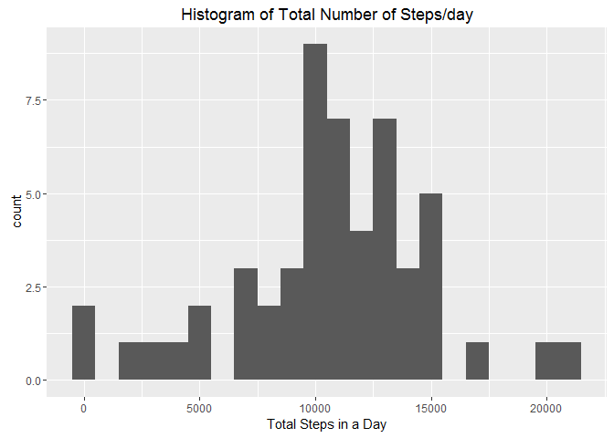

```r
ggplot(tsteps, aes(steps)) + geom_histogram(binwidth=1000, na.rm = FALSE) +
        xlab("Total Steps in a Day") +
        ggtitle("Histogram of Total Number of Steps/day" )
```

## What is the average daily activity pattern?

Following line graph gives the average daily activity pattern where variation of average steps for a particular time interval

```r
tsAvgIntSteps <- sqldf('select interval, avg(steps) AvgSteps from repData group by interval')
```

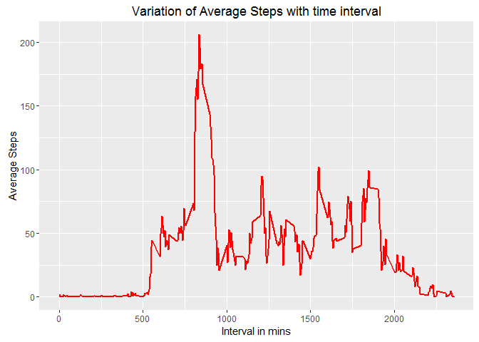

```r
ggplot(tsAvgIntSteps, aes(interval, AvgSteps )) + geom_line(colour="red",
        size=1.0, na.rm=FALSE)  + xlab("Interval in mins") +
        ylab("Average Steps") +
        ggtitle("Variation of Average Steps with time interval" )
```

```r
sqldf('select  interval, max(AvgSteps) from tsAvgIntSteps')
```

```
##   interval max(AvgSteps)
## 1      835      206.1698
```

## Imputing missing values

Analysis of missing values

```r
md.pattern(repData)
```

```
##       date interval steps
## 15264    1        1     1    0
##  2304    1        1     0    1
##          0        0  2304 2304
```

it shows that 2304 records are having steps missing.

Now impute missing data by using mice package using predictor mean method for filling the missing values. Then find the mean and median values

```r
tempRepData <- mice(repData,m=1,maxit=50,meth='mean',seed=50)
summary(tempRepData)
```

```
## Multiply imputed data set
## Call:
## mice(data = repData, m = 1, method = "mean", maxit = 50, seed = 50)
## Number of multiple imputations:  1
## Missing cells per column:
##    steps     date interval
##     2304        0        0
## Imputation methods:
##    steps     date interval
##   "mean"   "mean"   "mean"
## VisitSequence:
## steps
##     1
## PredictorMatrix:
##          steps date interval
## steps        0    1        1
## date         0    0        0
## interval     0    0        0
## Random generator seed value:  50
```

```r
completedData <- complete(tempRepData,1)
tstepsMod <- aggregate(steps ~ date, data=completedData, FUN=sum)
summary(tstepsMod)
```

```
##          date        steps
##  2012-10-01: 1   Min.   :   41
##  2012-10-02: 1   1st Qu.: 9819
##  2012-10-03: 1   Median :10766
##  2012-10-04: 1   Mean   :10766
##  2012-10-05: 1   3rd Qu.:12811
##  2012-10-06: 1   Max.   :21194
##  (Other)   :55
```

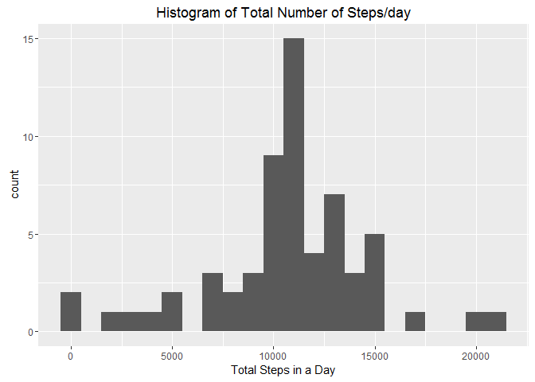

```r
ggplot(tstepsMod, aes(steps)) + geom_histogram(binwidth=1000, na.rm = FALSE) +
        xlab("Total Steps in a Day") +
        ggtitle("Histogram of Total Number of Steps/day" )
```

## Are there differences in activity patterns between weekdays and weekends?

Using data frame which has been imputed for further analysis to see the activity patterns differences between weekdays and weekends.

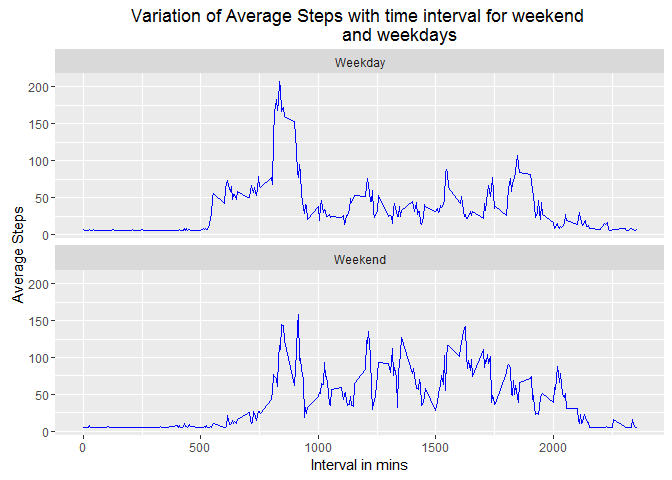

```r
completedData$dayType <- as.factor(ifelse(weekdays(as.Date(completedData$date)) %in%
         c("Saturday", "Sunday"), "Weekend", "Weekday"))

tsAvgIntStepsMod <- sqldf('select interval, avg(steps) AvgSteps, dayType
        from completedData group by interval, dayType')


ggplot(tsAvgIntStepsMod, aes(interval, AvgSteps))+geom_line(color="blue")+
        facet_wrap(~dayType, ncol=1) +
        xlab("Interval in mins") +
        ylab("Average Steps") +
        ggtitle("Variation of Average Steps with time interval for weekend
                and weekdays" )
```

From the comparison plot we can see that average steps are slightly more for weekends when compared to weekdays, however the max average steps(Peak) is lower for weekend.